# STA4173: Project 1

Brittany Lane

Last updated: 2021-09-16

#### 1. Describe the data.

```r
summaries <- data_south_west %>% group_by(Region) %>%
  summarize(mean00 = mean(`2000`), sd00 = sd(`2000`), median00 = median(`2000`), iqr00 = IQR(`2000`), mean05 = mean(`2005`), sd05 = sd(`2005`), median05= median(`2005`), iqr05= IQR(`2005`), mean10 = mean(`2010`), sd10 = sd(`2010`), median10 = median(`2010`), iqr10 = IQR(`2010`),mean15 = mean(`2015`), sd15 = sd(`2015`), median15 = median(`2015`), iqr15 = IQR(`2015`))

# NOTE -- you must edit the code in this chunk to get the summary statistics for the other years (copy, paste, and edit :-) )
```

|  |  | 2000 | 2005 | 2010 | 2015 |
| --- | --- | --- | --- | --- | --- |
| South | Mean (Standard Deviation) | 132076.06 (109494.66) | 154574.41 (131346.59) | 170491.35 (160772.71) | 167942.41 (135909.16) |
|  | Median (IQR) | 86312 (133005) | 98418 (126445) | 124954 (142669) | 121326 (108270) |
| West | Mean (Standard Deviation) | 153955.29 (255145.33) | 194852.93 (317818.93) | 200260.07 (313317.25) | 209893.5 (334242.01) |
|  | Median (IQR) | 70712 (127267.75) | 105808 (143534.75) | 93511 (175447.25) | 98848 (171893) |

#### 2. Construct side-by-side boxplots comparing the South and West regions for 2000, 2005, 2010, and 2015.

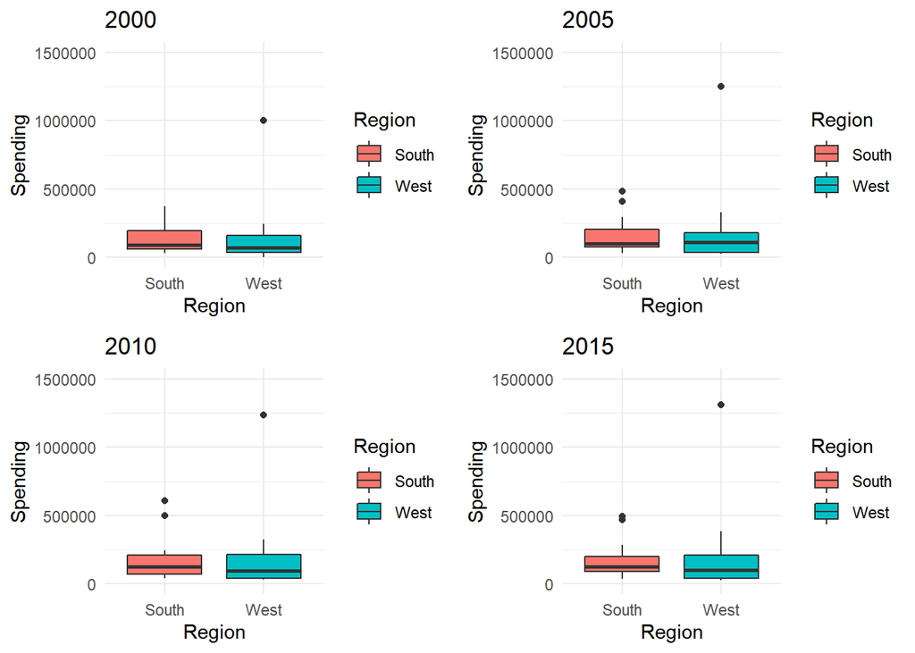

```r
bp00 <- ggplot(data=data_south_west, aes(y= `2000`, x=Region, fill=Region)) +
          geom_boxplot() +
          theme_minimal() +
          labs(y = "Spending", x = "Region") +
          ylim(min=0, max=1500000) +
          ggtitle("2000")

bp05 <- ggplot(data=data_south_west, aes(y= `2005`, x=Region, fill=Region)) +
          geom_boxplot() +
          theme_minimal() +
          labs(y = "Spending", x = "Region") +
          ylim(min=0, max=1500000) +
          ggtitle("2005")

bp10 <- ggplot(data=data_south_west, aes(y= `2010`, x=Region, fill=Region)) +
          geom_boxplot() +
          theme_minimal() +
          labs(y = "Spending", x = "Region") +
          ylim(min=0, max=1500000) +
          ggtitle("2010")
bp15 <- ggplot(data=data_south_west, aes(y= `2015`, x=Region, fill=Region)) +
          geom_boxplot() +
          theme_minimal() +
          labs(y = "Spending", x = "Region") +
          ylim(min=0, max=1500000) +
          ggtitle("2015")

# NOTE -- you must edit the code to be able to construct the final image (below) -- copy, paste, and change values to get the boxplots together, below

ggarrange(bp00, bp05, bp10, bp15, ncol=2, nrow=2)
```

#### 4. Use the appropriate *t* test to determine if there is a difference in library spending between the South and West regions in 2005. Test at the α = 0.05 level. Include the formal test results (including the formal hypotheses), but in your interpretation, make sure that you explain the results such that a non-statistician can understand.

#### 5. Assess the variance assumption. Test at the α = 0.05 level. Include the formal test results (including the formal hypotheses), but in your interpretation, make sure that you explain the results such that a non-statistician can understand. Include whether or not the assumption is broken.

#### 6. Assess the normality assumption. In your interpretation, make sure that you explain the results such that a non-statistician can understand. Include whether or not the assumption is broken.

#### 7. Use the appropriate nonparametric test to determine if there is a difference in library spending between the South and West regions in 2005. Test at the α = 0.05 level. Include the formal test results (including the formal hypotheses), but in your interpretation, make sure that you explain the results such that a non-statistician can understand.

#### 8. Based on your answers to 5 and 6, which test should be reported? Explain why you’re choosing the test you’re choosing. (Hint: you will either choose the *t* test or the nonparametric test.)

#### 9. Use the appropriate *t* test to determine if there is a difference in library spending between 2005 and 2010 for all states. Test at the α = 0.05 level. Include the formal test results (including the formal hypotheses), but in your interpretation, make sure that you explain the results such that a non-statistician can understand.

#### 10. Assess the normality assumption. In your interpretation, make sure that you explain the results such that a non-statistician can understand. Include whether or not the assumption is broken.

#### 11. Use the appropriate nonparametric test to determine if there is a difference in library spending between 2005 and 2010 for all states. Test at the α = 0.05 level. Include the formal test results (including the formal hypotheses), but in your interpretation, make sure that you explain the results such that a non-statistician can understand.

#### 12. Based on your answers to 10, which test should be reported? Explain why you’re choosing the test you’re choosing. (Hint: you will either choose the *t* test or the nonparametric test.)